# Web Traffic Data Exploration

## with Linear Regression Analysis

## Part 2: Preparation for Running Linear Regression Analysis

### A note on Independent and Dependent Variables for this exercise

- Considering the web traffic metrics, in 'cause and effect' terms for this exercise; Users can be considered as the independent variable because data for the other dependent metrics wouldn't exist if it weren't for the Users.
- This mean Users is being used as the predictor (X) in order to determine other metrics (y)
- **However**, in real-world terms, independent variables should refer to a metric which can be controlled e.g. 'Monthly Campaign Investment'. The reality is that the number of Users engaging with a specific website in a month isn't pre-determined!
- Technically, the number of Users would actually be dependent on other independent variables.

## Understanding Prerequisites

- At the top level, we want to understand how metrics relate to each other.
- As presented earlier, questions can be answered such as "How many Sessions and Pageviews can be expected if there are x number of Users?".
- However, in order to get there with help of Linear Regression, various prerequisites are required.

### Prerequisites: 1) Linearity and 2) Normal Distribution

- The relationship between independent and dependent variables should be **linear**
- The way datapoints are distributed for metrics should conform to a **normal distribution**

With this in mind, an initial pairplot analysis can be run to test these points, with support of pandas and seaborn. Beforehand, adjustments can be made to the web_traffic_df pandas dataframe to accommodate this.

### Adjusting the dataframe

- A copy of the primary dataframe is made for some initial analysis
- 'Month of Year', alongside 'Date Range' are removed as columns to keep this simple
- This is to help ensure attributes in the primary dataframe read from the CSV earlier are preserved

```python
import pandas as pd

web_traffic_df = pd.read_csv('../assets/GA_web_traffic_data_12_08_20.csv')
```

```
web_traffic_df_copy = web_traffic_df.copy()
web_traffic_df_copy.drop(['Month of Year', 'Date Range'], axis=1, inplace=True)
metrics_only.info()
```

```python
web_traffic_df_copy = web_traffic_df.copy()
web_traffic_df_copy.drop(['Month of Year', 'Date Range'], axis=1, inplace=True)
web_traffic_df_copy.info()
```

```
<class 'pandas.core.frame.DataFrame'>
RangeIndex: 195 entries, 0 to 194
Data columns (total 7 columns):
 #   Column                 Non-Null Count  Dtype
---  ------                 --------------  -----
 0   Segment                195 non-null    object
 1   Users                  195 non-null    int64
 2   Page Views             195 non-null    int64
 3   Sessions               195 non-null    int64
 4   Avg. Session Duration  195 non-null    float64
 5   Pages/Session          195 non-null    float64
 6   Bounce Rate            195 non-null    object
dtypes: float64(2), int64(3), object(2)
memory usage: 10.8+ KB
```

### Using seaborn Pairplot

Here, seaborn is used to produce a pairplot. Kernel Density Estimation (KDE) plots are shown in an diagonal arrangement to help understand the distribution of datapoints for metrics:

```
import seaborn as sns
import matplotlib.pyplot as plt
%matplotlib inline

sns.pairplot(metrics_only, diag_kind="kde")
```

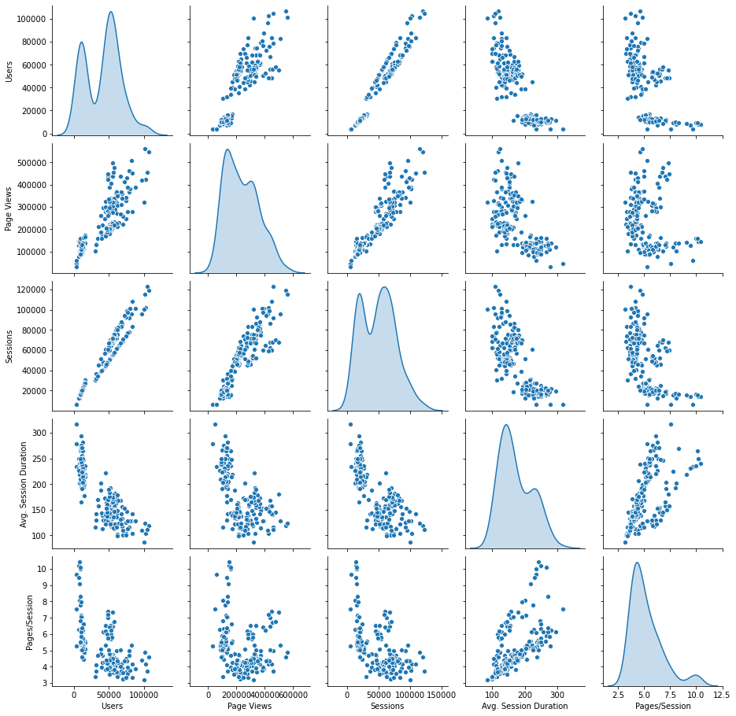

```python
import seaborn as sns
import matplotlib.pyplot as plt
%matplotlib inline
sns.pairplot(web_traffic_df_copy, diag_kind="kde")
```

### Pairplot Findings

- **Linearity**: The number of users shows a positive correlation with monthly datapoints provided for Sessions and Pageviews, supporting that these metrics can be passed to a Linear Regression model
- **Normal Distribution**: Whilst a normal distribution is evident for Page Views, Users and Sessions appear to show a bimodal distribution of data points warranting further investigation

### Using seaborn FacetGrid with histograms

Producing histograms for each user Segment can help deduce whether this is responsible for the bimodal distribution

```
histo_grid = sns.FacetGrid(web_traffic_df_copy, col="Segment")
histo_grid = histo_grid.map(plt.hist, "Users", bins=50, color="r")
```

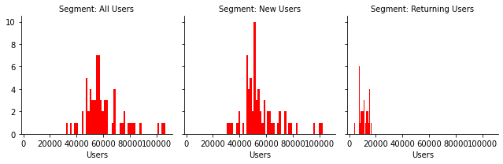

```python
histo_grid = sns.FacetGrid(web_traffic_df_copy, col="Segment")
histo_grid = histo_grid.map(plt.hist, "Users", bins=50, color="r")
histo_grid.set_titles("Segment: {col_name}")
```

```
histo_grid = sns.FacetGrid(web_traffic_df_copy, col="Segment")
histo_grid = histo_grid.map(plt.hist, "Users", bins=50, color="r")
```

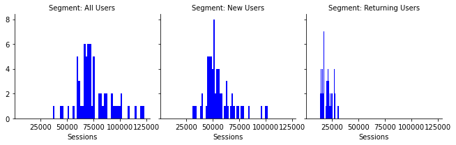

```python
histo_grid = sns.FacetGrid(web_traffic_df_copy, col="Segment")
histo_grid = histo_grid.map(plt.hist, "Sessions", bins=50, color="b")
histo_grid.set_titles("Segment: {col_name}")
```

### Prerequisite: 3) Multicollinearity

- **Multicollinearity** should be kept to a minimal

**Pearson's standard correlation coefficient** is one of several tests for measuring Multicollinearity

## Using seaborn FacetGrid with Heat Maps

- Seaborn and pandas can be used to produce a matrix to show the **Pearson's standard correlation coefficient** between metrics. Heat maps show a distinction for scenarios where a) All Segments are considered and b) Returning Users are excluded.
- A new dataframe; 'all_and_new_users_only' is produced which considers scenario b)
- A function is set up to map heatmaps to a matplotlib figure

```
all_and_new_users_only = web_traffic_df_copy[(web_traffic_df_copy['Segment']=='All Users')
                                             | (web_traffic_df_copy['Segment']=='New Users')]

def create_heatmap(df, title, pyplot_no):
    #pyplot_no refers to subplot location e.g. 121 refers to 1st row, 2 columns and plot number 1 (top left)
    # https://stackoverflow.com/questions/1616427/trying-to-position-subplots-next-to-each-other
    plt.subplot(pyplot_no)
    ax = sns.heatmap(df.corr(), annot=True, linewidths=.5, vmin=-0.8, vmax=1, cmap="BuPu")
    ax.set_title(title)
    ax.set_xticklabels(ax.get_xticklabels(), rotation=30)
    ax.set_yticklabels(ax.get_yticklabels(), rotation=30)

plt.figure(figsize=(17, 4.5))
create_heatmap(web_traffic_df_copy, 'Scenario 1: All Segments\n', 121)
create_heatmap(all_and_new_users_only, 'Scenario 2: All Users and New Users\n', 122)
```

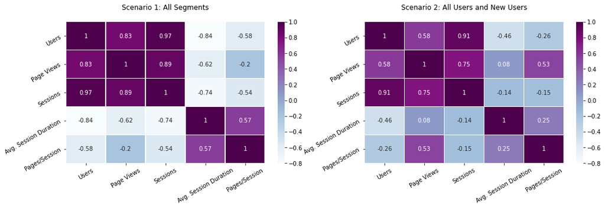

```python
all_and_new_users_only = web_traffic_df_copy[(web_traffic_df_copy['Segment']=='All Users')
                                             | (web_traffic_df_copy['Segment']=='New Users')]

def create_heatmap(df, title, pyplot_no):
    #pyplot_no refers to subplot location e.g. 121 refers to 1st row, 2 columns and plot number 1 (top left)
    # https://stackoverflow.com/questions/1616427/trying-to-position-subplots-next-to-each-other
    plt.subplot(pyplot_no)
    ax = sns.heatmap(df.corr(), annot=True, linewidths=.5, vmin=-0.8, vmax=1, cmap="BuPu")
    ax.set_title(title)
    ax.set_xticklabels(ax.get_xticklabels(), rotation=30)
    ax.set_yticklabels(ax.get_yticklabels(), rotation=30)

plt.figure(figsize=(17, 4.5))
create_heatmap(web_traffic_df_copy, 'Scenario 1: All Segments\n', 121)
create_heatmap(all_and_new_users_only, 'Scenario 2: All Users and New Users\n', 122)
```

### Summary of findings

- At this point, it has been identified proceeding to work with the Scenario 2 dataframe; all_and_new_users_only, helps ensure prerequisites for linear regression analysis thus far are being met.
- Users, Sessions and Page Views all have a linear relationship, are normally distributed and in Scenario 2 have a reduced risk of Multicollinearity
- However, please note reducing a considerble number of rows (aka entries) means there are not as many datapoints for the linear regression model. It goes without saying, the more data the better, particularly for the real world! This concerns accuracy trade-offs.
- Removing Returning Users, means a third of the dataframe has been lost (130 rows down from 195 rows):

```
all_and_new_users_only.info()
```

```python
all_and_new_users_only.info()
```

```
<class 'pandas.core.frame.DataFrame'>
Int64Index: 130 entries, 0 to 193
Data columns (total 7 columns):
 #   Column                 Non-Null Count  Dtype
---  ------                 --------------  -----
 0   Segment                130 non-null    object
 1   Users                  130 non-null    int64
 2   Page Views             130 non-null    int64
 3   Sessions               130 non-null    int64
 4   Avg. Session Duration  130 non-null    float64
 5   Pages/Session          130 non-null    float64
 6   Bounce Rate            130 non-null    object
dtypes: float64(2), int64(3), object(2)
memory usage: 8.1+ KB
```

### Further points on requirements for Linear Regression

Whilst there are tests that can be run prior to Linear Regression Analysis, there are tests for Autocorrelation and Homoscedasticity that can be run afterwards to validate whether various metrics are suited to the model

[Next Page: Part 3 - Running Linear Regression with sklearn](https://htmlpreview.github.io/?https://github.com/Kremzeeq/ga_linear_regression_project/blob/master/webpages/GA_Linear_Regression_Analysis_P3.html)

```python
%%html
<style>
div.input {
    display:none;
}

</style>
```